# A Classification problem solution attempt with Decision Tree Classifiers, Random Forest Classifiers, Artificial Neural Networks, Gradient Boosting Classifier, K-Neighbors Classifier & Logistic Regress

### Best parameter by RandomSearchCV package

GridSearchCV is computationally-time expensive, especially when searching over a large hyperparameter space and dealing with multiple hyperparameters. A solution to this is to use RandomizedSearchCV, in which not all hyperparameter values are tried out. Instead, a fixed number of hyperparameter settings is sampled from specified probability distributions.

```python
def build_model(optimizer,kernel, units):
    model = Sequential()
    #First Hidden Layer
    model.add(Dense(units=units,  kernel_initializer= kernel, activation='relu', input_dim=10))
    model.add(Dropout(0.1))
    #Second  Hidden Layer
    model.add(Dense(units=units,  kernel_initializer=kernel, activation='relu'))
    model.add(Dropout(0.1))
    #Output Layer
    model.add(Dense(units=1,  kernel_initializer=kernel, activation='sigmoid'))

    #Compiling the neural network
    model.compile(optimizer=optimizer, loss='binary_crossentropy', metrics=['accuracy'])
    return model

keras_clf = KerasClassifier(build_model)#,epochs=200, batch_size=100)
```

Proving values for

```python
params_ann ={'batch_size':range(10,150),
            'epochs':range(10,200),
            'optimizer':['adam','rmsprop','SGD'],
            'kernel':['uniform'],
            'units':range(4,16)}
```

The *batch_size* is a hyperparameter that defines the number of samples to work through before updating the internal model parameters.

The number of *epochs* is a hyperparameter that defines the number times that the learning algorithm will work through the entire training dataset.

The *kernel* is a filter that is used to extract the features. The kernel is a matrix that moves over the input data, performs the dot product with the sub-region of input data, and gets the output as the matrix of dot products.

*Optimizers* are algorithms or methods used to change the attributes of the neural network such as weights and learning rate to reduce the losses.

The package realize cross-validation in 5 groups with "accuracy" as the parameter of scoring

```python
ann_RS = RandomizedSearchCV(estimator=keras_clf, param_distributions=params_ann, n_iter = 20, scoring='accuracy', cv =5, verbose=2, random_state=0, n_jobs=-1)
```

```python
ann_result = ann_RS.fit(train_X,train_y)
ann_params = ann_result.best_params_
ann_params
```

```
Fitting 5 folds for each of 20 candidates, totalling 100 fits
```

```
[Parallel(n_jobs=-1)]: Using backend LokyBackend with 4 concurrent workers.
[Parallel(n_jobs=-1)]: Done  33 tasks      | elapsed:  9.0min
[Parallel(n_jobs=-1)]: Done 100 out of 100 | elapsed: 24.5min finished
```

```
{'units': 13,
 'optimizer': 'adam',
 'kernel': 'uniform',
 'epochs': 98,
 'batch_size': 54}
```

```python
classifier=build_model(ann_params["optimizer"],ann_params["kernel"],ann_params["units"])
```

```python
history=classifier.fit(train_X, train_y, validation_data=(val_X, val_y),
                       epochs=ann_params["epochs"], batch_size=ann_params["batch_size"])
```

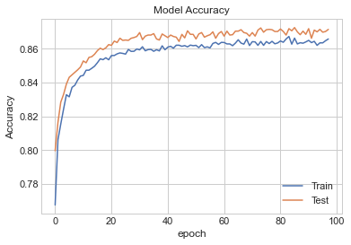

```python
figsize=(30,20)
# Model accuracy
plt.plot(history.history['accuracy'])
plt.plot(history.history['val_accuracy'])
plt.title('Model Accuracy')
plt.ylabel('Accuracy')
plt.xlabel('epoch')
plt.legend(['Train', 'Test'])
plt.show()
```

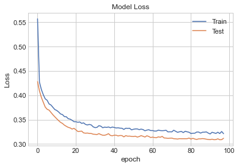

```python
# Model Losss
plt.plot(history.history['loss'])
plt.plot(history.history['val_loss'])
plt.title('Model Loss')
plt.ylabel('Loss')
plt.xlabel('epoch')
plt.legend(['Train', 'Test'])
plt.show()
```

Confusion matrix:

```python
# Predicting the Test set results
y_pred = classifier.predict(val_X)
y_pred = (y_pred > 0.5)
# Making the Confusion Matrix
cm = confusion_matrix(val_y, y_pred)
#sns.heatmap(cm,annot=True)
print(cm)
print()
ac7b=(cm[0][0] + cm[1][1])/sum(sum(cm))
print(f"The accuracy is {ac7b}")
```

```
[[1213  463]
 [ 148 2931]]

The accuracy is 0.871503680336488
```

It is too computational expensive to re-run this classificator to reevaluate and produce the formated confusion matrix, but it follows the same format of the other matrices:

|  | Predicted F | Predicted T |
| --- | --- | --- |
| True F | 1213 | 463 |
| True T | 148 | 2931 |

#### ROC curve

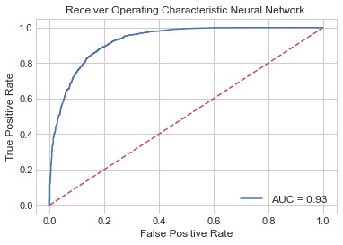

```python
probs = classifier.predict(val_X)
preds = probs
fprd, tprd, thresholdd = roc_curve(val_y, preds)
roc_aucd = auc(fprd, tprd)

plt.plot(fprd, tprd, 'b', label = 'AUC = %0.2f' % roc_aucd)
plt.plot([0, 1], [0, 1],'r--')
plt.title('Receiver Operating Characteristic Neural Network ',fontsize=12)
plt.ylabel('True Positive Rate',fontsize=12)
plt.xlabel('False Positive Rate',fontsize=12)
plt.legend(loc = 'lower right', prop={'size': 12})
r7b=roc_aucd
rx7b=fprd
ry7b=tprd
plt.show()
```

#### Cross validation

```python
def build_model_CV_best():
    optimizer=ann_params["optimizer"]
    kernel=ann_params["kernel"]
    units=ann_params["units"]
    model = Sequential()
    #First Hidden Layer
    model.add(Dense(units=units,  kernel_initializer= kernel, activation='relu', input_dim=10))
    model.add(Dropout(0.1))
    #Second  Hidden Layer
    model.add(Dense(units=units,  kernel_initializer=kernel, activation='relu'))
    model.add(Dropout(0.1))
    #Output Layer
    model.add(Dense(units=1,  kernel_initializer=kernel, activation='sigmoid'))

    #Compiling the neural network
    model.compile(optimizer=optimizer, loss='binary_crossentropy', metrics=['accuracy'])
    return model

keras_clfCV_best = KerasClassifier(build_model_CV_best,epochs=ann_params["epochs"], batch_size=ann_params["batch_size"])
```

```python
with HiddenPrints():
  score7b = cross_val_score(estimator=keras_clfCV_best,  X=X_s, y=y,cv=5, scoring='accuracy')
```

```python
print('Mean Accuracy Score ANN w best parameters: %2f' %(score7b.mean()))
```

```
Mean Accuracy Score ANN w best parameters: 0.826183
```

## Gradient Boost Classifier

### No boosted parameters

```python
gbc = GradientBoostingClassifier()
gbc.fit(train_X, train_y)

# Make validation predictions and calculate precition
print_score(gbc, train_X, train_y, val_X, val_y, train=False)
```

```
Test Result:
===========================================
accuracy score: 0.8719242902208202

Classification Report:
 	Precision: 0.8662514827995255
	Recall Score: 0.9486846378694381
	F1 score: 0.9055960316230042

Confusion Matrix:

+----------+---------------+---------------+
|          |   Predicted F |   Predicted T |
|----------+---------------+---------------|
| True F   |          1225 |           451 |
| True T   |           158 |          2921 |
+----------+---------------+---------------+

Relative Confusion Matrix:

+----------+---------------+---------------+
|          |   Predicted F |   Predicted T |
|----------+---------------+---------------|
| True F   |        0.731  |         0.269 |
| True T   |        0.0513 |         0.949 |
+----------+---------------+---------------+
```

```python
#saving the result for later
#pudo ir antes en la función de display de resultados pero me iba a costar tiempo reevaluar
ac8 =accuracy_score(val_y, gbc.predict(val_X))
```

#### ROC curve

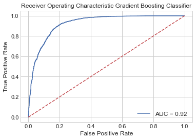

```python
(r8,rx8,ry8)=ROC_plot(gbc,'Gradient Boosting Classifier')
```

#### Cross validation

```python
score8  =cross_val_score(gbc, X, y, cv=5, scoring='accuracy')# in 5 groups
print('Mean Accuracy Score GBC w no parameters: %2f' %(score8.mean()))
```

```
Mean Accuracy Score GBC w no parameters: 0.870978
```

### Best parameters given by GridSearchCV package

Grid search is the process of performing hyper parameter tuning in order to determine the optimal values for a given model. Also the function preforms cross-validation

```python
GBC = GradientBoostingClassifier(random_state = 0)
```

Proving values for

*n_estimators*: (default=100) The number of boosting stages to perform. Gradient boosting is fairly robust to over-fitting so a large number usually results in better performance.

*learning_rate*: (default=0.1) learning rate shrinks the contribution of each tree by learning_rate. There is a trade-off between learning_rate and n_estimators.

*max_depth*: (default=3) maximum depth of the individual regression estimators. The maximum depth limits the number of nodes in the tree. Tune this parameter for best performance; the best value depends on the interaction of the input variables.

```python
params_GBC={'n_estimators':range(50,200,50),
            'learning_rate':[0.05, 0.5, 1],
            'max_depth':[2,3,4]}
```

The package realize cross-validation in 5 groups with "accuracy" as the parameter of scoring

```python
GBC_GS = GridSearchCV(
        estimator=GBC,
        param_grid=params_GBC,
        cv=5, scoring='accuracy', verbose=0, n_jobs=-1)
```

```python
GBC_result = GBC_GS.fit(train_X,train_y)
GBC_params = GBC_result.best_params_
GBC_params
```

```
{'learning_rate': 0.5, 'max_depth': 3, 'n_estimators': 50}
```

```python
best_GBC=GradientBoostingClassifier(random_state = 0,
                                    n_estimators=GBC_params["n_estimators"],learning_rate=GBC_params["learning_rate"],
                                    max_depth=GBC_params['max_depth'])
best_GBC.fit(train_X,train_y);
print_score(best_GBC, train_X, train_y, val_X, val_y, train=False)
```

```
Test Result:
===========================================
accuracy score: 0.8797055730809674

Classification Report:
 	Precision: 0.8804248861911987
	Recall Score: 0.9421890224098733
	F1 score: 0.9102604330090994

Confusion Matrix:

+----------+---------------+---------------+
|          |   Predicted F |   Predicted T |
|----------+---------------+---------------|
| True F   |          1282 |           394 |
| True T   |           178 |          2901 |
+----------+---------------+---------------+

Relative Confusion Matrix:

+----------+---------------+---------------+
|          |   Predicted F |   Predicted T |
|----------+---------------+---------------|
| True F   |        0.765  |         0.235 |
| True T   |        0.0578 |         0.942 |
+----------+---------------+---------------+
```

```python
#saving the result for later
#pudo ir antes en la función de display de resultados pero me iba a costar tiempo reevaluar
ac9 =accuracy_score(val_y, best_GBC.predict(val_X))
```

#### ROC curve

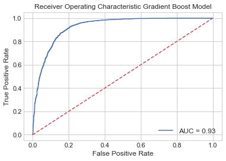

```python
(r9,rx9,ry9)=ROC_plot(best_GBC,"Gradient Boost Model")
```

#### Cross validation

```python
score9  =cross_val_score(best_GBC, X, y, cv=5, scoring='accuracy')
print('Mean Accuracy Score GBC w best parameters: %2f' %(score9.mean()))
```

```
Mean Accuracy Score GBC w best parameters: 0.871609
```

### Best parameter by RandomSearchCV package

GridSearchCV is computationally-time expensive, especially when searching over a large hyperparameter space and dealing with multiple hyperparameters. A solution to this is to use RandomizedSearchCV, in which not all hyperparameter values are tried out. Instead, a fixed number of hyperparameter settings is sampled from specified probability distributions.

```python
gbc = GradientBoostingClassifier(random_state = 0)
```

Proving values for

*n_estimators*: (default=100) The number of boosting stages to perform. Gradient boosting is fairly robust to over-fitting so a large number usually results in better performance.

*learning_rate*: (default=0.1) learning rate shrinks the contribution of each tree by learning_rate. There is a trade-off between learning_rate and n_estimators.

*max_depth*: (default=3) maximum depth of the individual regression estimators. The maximum depth limits the number of nodes in the tree. Tune this parameter for best performance; the best value depends on the interaction of the input variables.

```python
params_gbc={'n_estimators':range(50,200),
            'learning_rate':[i/100. for i in range(5,101)],
            'max_depth':range(2,4)}
```

Proving values for

The package realize cross-validation in 5 groups with "accuracy" as the parameter of scoring

```python
gbc_RS = RandomizedSearchCV(estimator=gbc, param_distributions=params_gbc,
                            n_iter = 20, scoring='accuracy', cv =5, verbose=2, random_state=0, n_jobs=-1)
```

```python
gbc_result = gbc_RS.fit(train_X,train_y)
gbc_params = gbc_result.best_params_
gbc_params
```

```
Fitting 5 folds for each of 20 candidates, totalling 100 fits
```

```
[Parallel(n_jobs=-1)]: Using backend LokyBackend with 4 concurrent workers.
[Parallel(n_jobs=-1)]: Done  33 tasks      | elapsed:  1.5min
[Parallel(n_jobs=-1)]: Done 100 out of 100 | elapsed:  4.1min finished
```

```
{'n_estimators': 180, 'max_depth': 2, 'learning_rate': 0.56}
```

```python
best_gbc=GradientBoostingClassifier(random_state = 0,
                                    n_estimators=gbc_params["n_estimators"],learning_rate=gbc_params["learning_rate"],
                                    max_depth=gbc_params['max_depth'])
best_gbc.fit(train_X,train_y);
print_score(best_gbc, train_X, train_y, val_X, val_y, train=False)
```

```
Test Result:
===========================================
accuracy score: 0.8792849631966351

Classification Report:
 	Precision: 0.8829104249464995
	Recall Score: 0.9379668723611562
	F1 score: 0.9096062992125984

Confusion Matrix:

+----------+---------------+---------------+
|          |   Predicted F |   Predicted T |
|----------+---------------+---------------|
| True F   |          1293 |           383 |
| True T   |           191 |          2888 |
+----------+---------------+---------------+

Relative Confusion Matrix:

+----------+---------------+---------------+
|          |   Predicted F |   Predicted T |
|----------+---------------+---------------|
| True F   |         0.771 |         0.229 |
| True T   |         0.062 |         0.938 |
+----------+---------------+---------------+
```

```python
#saving the result for later
#pudo ir antes en la función de display de resultados pero me iba a costar tiempo reevaluar
ac9b =accuracy_score(val_y, best_gbc.predict(val_X))
```

#### ROC curve

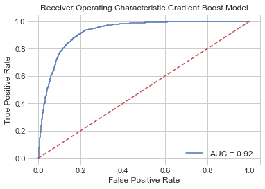

```python
(r9b,rx9b,ry9b)=ROC_plot(best_gbc,"Gradient Boost Model")
```

#### Cross validation

```python
score9b  =cross_val_score(best_gbc, X, y, cv=5, scoring='accuracy')
print('Mean Accuracy Score GBC w best parameters: %2f' %(score9b.mean()))
```

```
Mean Accuracy Score GBC w best parameters: 0.875815
```

## K-Near Neighbors

### No boosted parameters

```python
KNC = KNeighborsClassifier()
KNC.fit(train_X, train_y)

# Make validation predictions and calculate precition
print_score(KNC, train_X, train_y, val_X, val_y, train=False)
```

```
Test Result:
===========================================
accuracy score: 0.8317560462670873

Classification Report:
 	Precision: 0.8251069900142654
	Recall Score: 0.9392659954530692
	F1 score: 0.8784933171324423

Confusion Matrix:

+----------+---------------+---------------+
|          |   Predicted F |   Predicted T |
|----------+---------------+---------------|
| True F   |          1063 |           613 |
| True T   |           187 |          2892 |
+----------+---------------+---------------+

Relative Confusion Matrix:

+----------+---------------+---------------+
|          |   Predicted F |   Predicted T |
|----------+---------------+---------------|
| True F   |        0.634  |         0.366 |
| True T   |        0.0607 |         0.939 |
+----------+---------------+---------------+
```

```python
#saving the result for later
#pudo ir antes en la función de display de resultados pero me iba a costar tiempo reevaluar
ac10 =accuracy_score(val_y, KNC.predict(val_X))
```

#### ROC curve

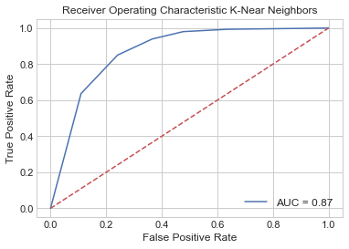

```python
(r10,rx10,ry10)=ROC_plot(KNC,'K-Near Neighbors')
```

#### Cross validation

```python
score10  =cross_val_score(KNC, X, y, cv=5, scoring='accuracy')# in 5 groups
print('Mean Accuracy Score KNN w no parameters: %2f' %(score10.mean()))
```

```
Mean Accuracy Score KNN w no parameters: 0.838223
```